# Notes for MATH 6391: Topics in Applied Mathematics (Fall 2021)

**Definition 3.** Let $f=\sum_{\alpha}^{}a_\alpha x^{\alpha}$ be a polynomial in $k[x_1,\cdots,x_n]$.  
(i) We call $a_\alpha$ the **coefficient** of the monomial $x^{\alpha}$.  
(ii) If $a_\alpha \ne 0$, then we call $a_\alpha x^{\alpha}$ a **term** of $f$.  
(iii) The **total degree** of $f\ne0$ (polynomial), denoted deg($f$), is the maximum $|\alpha|$ such that the coefficients $a_\alpha$ is nonzero. The total degree of the zero polynomial is undefined.

**Definition 4.** Given a field $k$ and a positive integer $n$, we define the *n*-dimensional **affine space** over $k$ to be the set $$k^{n}={(a_1,...,a_n)|a_1,...,a_n \in k)}$$

[Affine space](https://en.wikipedia.org/wiki/Affine_space): "In mathematics, an affine space is a geometric structure that generalizes some of the properties of Euclidean spaces in such a way that these are independent of the concepts of distance and measure of angles, keeping only the properties related to parallelism and ratio of lengths for parallel line segments." (Wikipedia)

> **Affine Space:** An affine space $A$ over a field $K$ is a set together with a vector space $V$, and a free, transitive action of the additive group of $V$ on $A$. Explicitly, there exists a map $$+:A \times V \rightarrow A, (a,v) \mapsto a+v$$ (a) $a+0=0$ (Identity)
> (b) $(a+v)+w=a+(v+w)$ (Associativity)
> (c) The map $\mapsto a+v$ is a [bijection](https://en.wikipedia.org/wiki/Bijection) $V \rightarrow A$ for all $a \in A$ (Free, transitice)
> - Affine maps are the correct notion of maps between affine spaces: $$\text{affine map: }f(a+v)=f(a)+f(v)$$

> From YouTube video: *What is an...affine space?*: https://www.youtube.com/watch?v=c-iA43vPL9M

An affine map is a linear map that don't possess a fixed origin; the lack of a fixed origin allows one to mnove the origin with a tranlation vector. The transience of a affine map, allows for different perspective in a mapping; without the lost of the operations and properties of a linear map.

- Excelent YouTube videos to accompany these notes are the following:
  - *1.1.1 Fields, Monomials, Polynomials, and Affine Space Defined*: https://www.youtube.com/watch?v=OoamCt8iwhQ&list=PLuk3I0lb-B5VZglbeHfzOZ5QJKdABpQU4&index=1&t=215s
  - *What is an...affine space?*: https://www.youtube.com/watch?v=c-iA43vPL9M

    **Example #2**: $\F_3[x]$. Note $\F_3=[0,1,2]$ field with mod $3 \; +$ (addition) and $*$ (multiplication). Consider $f=x^{3}-x$,

So $f$ as a function sends all elements in $\F^{3}$ to $0$. Hence $f$ is the $0$-function, but is not the $0$-polynomial. $\square$</p>

Needed consideration for $f=0$? There are two meanings of $f=0$.

1. **Zero polynomial:**
   - Is $f$ the zero polynomial?
   - Are all coefficients $a_\alpha = 0$? $f = \sum_{\alpha} 0*x^{\alpha}$
2. **Zero function:**
   - Is $f$ the zero function?
   - Us $f(a_1,...,a_n)=0$ for all $(a_1,...,a_n) \in k^{n}$?

     **Example #3:** Let $f \in \F_{2}[x]$, then consider $f = 1*x+1*x^{2}$.

$$f(0)=0+0^{2}=0+0=0$$$$f(1)=1+1^{2}=1+1^{2}=0$$

This is the zero function, but not the zero polynomial. Since $f(a)=a+a^{2}=0$ for all $a \in \in \F_{2} \Leftrightarrow a \in \{0,1\}$. $\square$

**Proponent 5.** Let $k$ be an *infinite field* and let $f \in k[x_1,\cdots,x_n]$. The $f=0$ ($f$ being the zero polynomial) in $k[x_1,\cdots,x_n]$ if and only if $f$: $k^{n} \rightarrow k$ is zero function.
**PROOF.** One direction of the proof is obvious since the zero polynomial clearly gives the zero function. To prove the converse, we need to show that if $f(a_1,\cdots,a_n)=0$ for all $(a_1,\cdots,a_n) \in k^{n}$, then $f$ is the zero polynomial. We will use induction on the number of variables $n$.
When $n=1$, it is well known that a nonzero polynomial in $k[x]$ of degree $m$ has at most $m$ distant roots (we will prove this fact in Corollary 3 of $\S$5). For our particular $f \in k[x]$, we are assuming $f(a)=0$ for all $a \in k$. Since $k$ is infinite, this means that $f$ has infinitely many roots, and hence, $f$ must be the zero polynomial.
Now assume that the converse is true for $n-1$, and let $f \in k[x_1,\cdots,x_n]$ be a polynomial that vanishes at all points of $k^{n}$. By collecting the various powers of $x_n$, we can write $f$ in the form $$f=\sum_{i=0}^{N}g_i(x_1,\cdots,x_{n-1})x_n^{i},$$ where $g_i \in k[x_1,\cdots,n_{n-1}]$. We will show that each $g_i$ is the zero polynomial in $n-1$ variables, which will force $f$ to be the zero polynomial in $k[x_1,\cdots,x_n]$.
If we fix $(a_1,\cdots,a_{n-1}) \in k^{n-1}$, we get the polynomial $f(a_1,\cdots,a_{n-1},x_n) \in k[x_n]$. By our hypothesis on $f$, this vanishes for every $a_n \in k$. It follows from the case $n=1$ that $f(a_1,\cdots,a_n-1,x_n)$ is the zero polynomial in $k[x_n]$. Using the above formula for $f$, we see that the coefficients of $f(a_1,\cdots,a_n-1,x_n)$ are $g_i(a_1,\cdots,a_n-1)$, and thus, $g_i(a_1,\cdots,a_n-1)=0$ for all $i$. Since $(a_1,\cdots,a_n-1)$ was arbitrarily chsen in $k^{n-1}$, it follows that each $g_i \in k[x_1,\cdots,x_n-1]$ gives the zero function on $k^{n-1}$. Our inductive assumption then implies that each $g_i$ is the zero polynomial in $k[x_1,\cdots,x_n-1]$. This forces $f$ to be the zero polynomial in $k[x_1,\cdots,x_n]$ and completes the proof of the proposition. $\square$

**Corollary 6**: Let $k$ be an infinite field, and let $f$, $g \in k[x_1,...,x_n]$. Then $f=g$ in $k[x_1,\cdots,x_n]$ if and only if $f$:$k^{n} \rightarrow k$ and $g$:$k^{n} \rightarrow k$ are the same function.  
**PROOF.** To prove the nontrivial direction, suppose that $f$, $g \in k[x_1,\cdots,x_n]$ give the same function on $k^{n}$. By hypothesis, the polynomial $f-g$ vanishes at all points of $k^{n}$. Proposition 5 then implies that $f-g$ is the zero polynomial. This proves that $f=g$ in $k[x_1,\cdots,x_n]$. $\square$

*Note*: In **Corollary 6.** $f=g$ in $k[x_1,...,x_n] \to$ which means that $f$ and $g$ have the same coefficients $a_\alpha \in k$.

**Theorem 7.** Every nonconstant polynomial $f \in \C[x]$ has a root in $\C$.  
**PROOF.** proof from another text: [**Proof.**](https://math.stackexchange.com/questions/1439302/question-regarding-the-proof-of-the-fundamental-theorem-of-algebra?rq=1.)  
Obversing the complexity of the proof, it is understable why the authors excluded this proof from the text. Much the contents of the proof are outside the scope of the text, and therefore abit of a stretch to include in the text for a reader to properly comphrehend, without the reader possessing a appropriate background, or understanding of the theorem and concepts invoke in the proof.

[**Fundamental Theorem of Algebra**](https://en.wikipedia.org/wiki/Fundamental_theorem_of_algebra): "Every polynomial equation having complex coefficients and degree $>=$1 has at least one complex root. This theorem was first proven by Gauss. It is equivalent to the statement that a polynomial $P(z)$ of degree n has n values $z_i$ (some of them possibly degenerate) for which $P(z_i)=0$. Such values are called polynomial roots. An example of a polynomial with a single root of multiplicity $>1$ is $z^2-2z+1=(z-1)(z-1)$, which has $z=1$ as a root of multiplicity 2." ([Wolfram.MathWorld](https://mathworld.wolfram.com/FundamentalTheoremofAlgebra.html))

Simply we are able to say that field $k$ is **algebraically closed** set, if every nonconstant polynomail $f \in k[x]$ possesses a root in $k$.  
Hence $\C$ is an algebraically closed field, but $\R$ is not. Hence, there are nonconstant polynomials $f \in k[x]$ that do not possess roots in $\R$.

- **Relevant Literature:**
  - Lankham, Isaiah, et al. “The Fundamental Theorem of Algebra.” Https://Www.math.ucdavis.edu,  
    University of California at Davis, 13 Feb. 2007, www.math.ucdavis.edu/~anne/WQ2007/mat67-Ld-FTA.pdf.

### $\S$ 1.2 Affine Varities

**Definition 1.** Let $k$ be a field, and let $f_1$,...,$f_s$ be a polynomials in $k[x_1,\cdots,x_n]$. Then we set $$ \textbf{V}(f_1,\cdots,f_s)=[{(a_1,\cdots,a_n) \in K^{k}|f_i(a_1,\cdots,a_n)=0 \text{ for all } 1 \leq i \leq s}].$$ We call $\textbf{V}(f_1,\cdots,f_s)$ the **affine variety** defined by $f_1$,...,$f_s$.

In essence an affine variety $\text{V}(f_1,...,f_s) \subseteq k^{n}$ is the set of all solution of a system of polynomail equations, such as,

$$ \begin{alignat*}{7} f_1(x_1,...&,x_n) = 0, \\ \vdots & & \\ f_s(x_1,...&,x_n) = 0. \\ \end{alignat*} $$

**Algebraic variety**:

> **Affine Variety:**

> For an algebraically closed field $k$ and a natural number $n$, let $A^{n}$ be [affine n-space](https://en.wikipedia.org/wiki/Affine_space) over $k$. The polynomials $f$ in the (polynomial) ring $k[x_1,...,x_n]$ can be viewed as $k$-valued function on $A^{n}$ by evaluating $f$ at the points in $A^{n}$, i.e. by choosing values in $k$ for each $x_i$. For each set $S$ of polynomials in $k[x_1,...,x_n]$, define the zero-locus $Z(S)$ to be the set of points in $A^{n}$ on which the function in $S$ simultaneously vanish, that is to say

> $$Z(S)-\{x \in A^{n} | f(x)=0 \text{ for all } f \in S\}$$

> A subset $V$ of $A^{n}$ is called an **affine algebraic set** if $V=Z(S)$ for some $S$. A nonempty affine algebraic set $V$ is called **irreducible** if it cannot be written as the union of two *proper* algebraic subsets. An irreducible affine algebraic set is also called an **affine variety**.

> (Wikipedia): *Algebraic variety:* https://en.wikipedia.org/wiki/Algebraic_variety

[**Affine variety**](https://en.wikipedia.org/wiki/Affine_variety):

> An affine variety V is an algebraic variety contained in affine space. For example, $$(x,y,z):x^{2}+y^{2}-z^{2}=0)$$ is the [cone](https://mathworld.wolfram.com/Cone.html), and $$[{(x,y,z):x^{2}+y^{2}-z^{2}=0,ax+by+cz=0}]$$ is a [conic section](https://mathworld.wolfram.com/ConicSection.html), which is a [subvariety](https://mathworld.wolfram.com/Subvariety.html) of the cone. The cone can be written $\text{V}(x^{2}+y^{2}-z^{2})$ to indicate that it is the variety corresponding to $x^{2}+y^{2}-z^{2}=0$. Naturally, many other polynomials vanish on $\text{V}(x^{2}+y^{2}-z^{2})$, in fact all polynomials in $I(C)={x^{2}+y^{2}-z^{2}}$. The set $I(C)$ is an [ideal](https://mathworld.wolfram.com/Ideal.html) in the polynomial ring $\C[x,y,z]$. Note also, that the ideal of [polynomials vanishing](https://mathworld.wolfram.com/PolynomialRing.html) on the conic section is the [ideal](https://mathworld.wolfram.com/Ideal.html) generated by $x^{2}+y^{2}-z^{2}$ and $ax+by+cz$.
> A [morphism](https://mathworld.wolfram.com/Morphism.html) between two affine varieties is given by polynomial coordinate functions. For example, the map $\phi(x,y,z)=(x^{2},y^{2},z^{2})$ is a [morphism](https://mathworld.wolfram.com/Morphism.html) from $X=\text{V}(x^{2}+y^{2}+z^{2})$ to $Y=\text{V}(x+y+z)$. Two affine varieties are [isomorphic](https://mathworld.wolfram.com/Isomorphic.html) if there is a [morphism](https://mathworld.wolfram.com/Morphism.html) which has an inverse morphism. For example, the affine variety $\text{V}(x^{2}+y^{2}+z^{2})$ is isomorphic to the cone $\text{V}(x^{2}+y^{2}-z^{2})$ via the coordinate change $\phi(x,y,z)=(x,y,iz)$.
> Many polynomials $f$ may be factored, for instance $f=x^{2}+y^{2}=(x+iy)(x-iy)$, and then $\text{V}(f)=\text{V}(x+iy)$ union $\text{V}(x-iy)$. Consequently, only [irreducible polynomials](https://mathworld.wolfram.com/IrreduciblePolynomial.html), and more generally only [prime ideals](https://mathworld.wolfram.com/PrimeIdeal.html) $p$ are used in the definition of a variety. An affine variety $\text{V}$ is the set of common zeros of a collection of polynomials $p_1,\cdots,p_k$, i.e., $$\text{V}=[x=(x_1,\cdots,x_n):p_1(x)=\cdots=p_k(x)=0]$$ as long as the [ideal](https://mathworld.wolfram.com/Ideal.html) $I=<p_1,...,p_k>$ is a [prime ideal](https://mathworld.wolfram.com/PrimeIdeal.html). More classically, an affine variety is defined by any set of polynomials, i.e., what is now called an [algebraic set](https://mathworld.wolfram.com/AlgebraicSet.html). Most points in $\text{V}$ will have dimension $n-k$, but $\text{V}$ may have singular points like the origin in the cone.
> When $\text{V}$ is one-dimensional generically (at almost all points), which typically occurs when $k=n-1$, then $\text{V}$ is called a curve.
> When $\text{V}$ is two-dimensional, it is called a surface. In the case of [CW-complex](https://mathworld.wolfram.com/CW-Complex.html) affine space, a curve is a [Riemann surface](https://mathworld.wolfram.com/RiemannSurface.html), possibly with some singularities." ([Wolfram.MathWorld](https://mathworld.wolfram.com/AffineVariety.html))

**Affine Transforms {Maps):**

> Let $(X,V,k)$ be an affine space of dimension at least two, with $X$ the point set and $V$ be the associated vector space over the field $k$. A *semiaffine transformation* $f$ of $X$ is a [bijection](https://en.wikipedia.org/wiki/Bijection) of $X$ onto itself satisfying.
> 1. If $S$ is a *d*-dimensional affine subspace of $X$, $f(S)$ is also a *d*-dimensional affine subspace of $X$.
> 2. If $S$ and $T$ are parallel affine subspaces of $X$, then $f(S)$||$f(T)$. These two conditions express what is precisely meant by the expression that "$f$ preserves parallelism".
>    These conditions are not independent as the second follows from the first. Furthermore, if the field $k$ has at least three elements, the first condition can be simplified to: $f$ is a [collineation](https://en.wikipedia.org/wiki/Collineation), that is, it maps lines to lines.
>    If the dimension of the affine space $(X,V,k)$ is at least two, then an **affine transformation** is a semiaffine transformation $f$ that satisfies the condition: **If** $x \ne >y$ and $p \ne q$ are points of $X$ such that the line segments $\overline{xy}$ and >$\overline{pq}$ are parallel, then $$\frac{\| \overline{pq} \|}{\| \overline{xy} \|}=\frac{\| \overline{f(p)f(q)} \|}{\| \overline{f(x)f(y)} \|}."$$

> (Wikipedia): *Affube transformation:* https://en.wikipedia.org/wiki/Affine_transformation

**Affine Line:**

> If the dimension of the affine space is one, that is, the space is an affine line, then any [permutation](https://en.wikipedia.org/wiki/Permutation) of $X$ would automatically satisfy the conditions to be a semiaffine transform. So, an affine transformation of an affine line is *defined* as any permutation $f$ of the points of $X$ such that if $X \ne y$ and $p \ne q$ are points of $X$, then $$\frac{\| \overline{pq} \|}{\| \overline{xy} \|}=\frac{\| \overline{f(p)f(q)} \|}{\| \overline{f(x)f(y)} \|}."$$

> (Wikipedia): *Affube transformation:* https://en.wikipedia.org/wiki/Affine_transformation

**Collineation:**

> "Simply, a colineation is a one-to-one (and onto map) from one projective space to another, or from a projective space to itself, such that the images of collinear points are themselves collinear. One may formalize this using various ways of presenting a projective space. Also, the case of the projective line is special, and hence generally treated differently."

> (Wikipedia): *Collineation:* https://en.wikipedia.org/wiki/Collineation

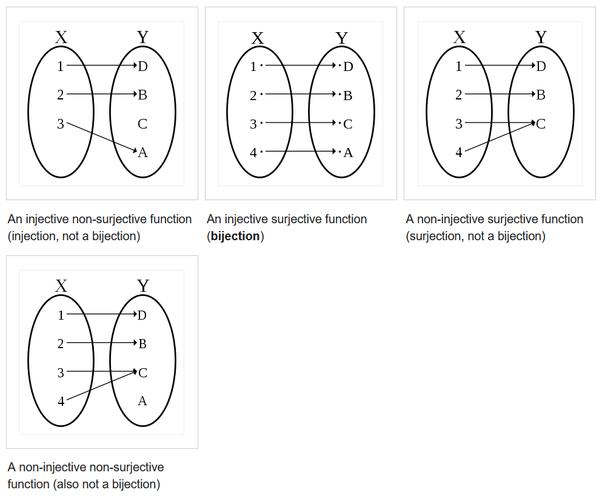

$$\text{Stole Bijection graphic from Wikipedia: Bijection:https://en.wikipedia.org/wiki/Bijection}$$

- **Relevant YouTube Videos:**  
  What is...an affine space? by VisualMath: https://www.youtube.com/watch?v=c-iA43vPL9M

  In summary, a polynomial $f = \sum_{\alpha} a_\alpha x^{\alpha} \in k[x_1,...,x_n]$ is defined as a function, given $(a_1,...,a_n) \in k^{n}$, replaces $x_i$ by $a_1$. And since $(a_1,..a_n) \in k$ and $a_\alpha \in k$, then $f(a_1,...,a_n) \in k$. And because $f$ is defined as a function we are able to map from $k^{n}$ to $k$ (e.g. $f: k^{n} \to k$, which means we can abridge algebra and geometry with this mapping.  
  To illustrate this mapping, the textbook provide several conventional and known geometric example. And as aforementioned, to illustrate these familiar curves and surfaces, we need $k$ to be the $\R$ field, so for the following graphic, know that $k = \R$. And also know that the following graphics were generated with Python code and a matplot python package and the numpy package.

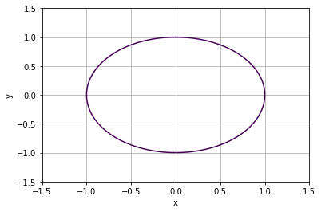

```python
import numpy as np
import matplotlib.pyplot as plt

x = np.linspace(-1.5, 1.5, 100)
y = np.linspace(-1.5, 1.5, 100)
X, Y = np.meshgrid(x,y)
F = X**2 + Y**2 - 1
plt.contour(X,Y,F,[0])
plt.grid()
plt.xlabel('x')
plt.ylabel('y')
```

**Conic section:** "The conic sections are the nondegenerate curves generated by the intersections of a [plane](https://mathworld.wolfram.com/Plane.html) with one or two [nappes](https://mathworld.wolfram.com/Nappe.html) of a [cone](https://mathworld.wolfram.com/Cone.html). For a [plane](https://mathworld.wolfram.com/Plane.html) perpendicular to the axis of the [cone](https://mathworld.wolfram.com/Cone.html), a circle is produced. For a plane that is not perpendicular to the axis and that [intersects](https://mathworld.wolfram.com/Intersection.html) only a single nappe, the curve produced is either an [ellipse](https://mathworld.wolfram.com/Ellipse.html) or a [parabola](https://mathworld.wolfram.com/Parabola.html) (Hilbert and Cohn-Vossen 1999, p. 8). The curve produced by a [plane](https://mathworld.wolfram.com/Plane.html) [intersecting](https://mathworld.wolfram.com/Intersection.html) both [nappes](https://mathworld.wolfram.com/Nappe.html) is a [hyperbola](https://mathworld.wolfram.com/Hyperbola.html) (Hilbert and Cohn-Vossen 1999, pp. 8-9)." ([Wolfram.MathWorld](https://mathworld.wolfram.com/ConicSection.html))

Equivalently conic sections are affine varieties, and likewise graphs of polynomial functions are affine varieties; e.g., the graph of $y=f(x)$ has an affine variety $\text{V}(y-f(x))$.  
This rational polynomial has an affine variety,

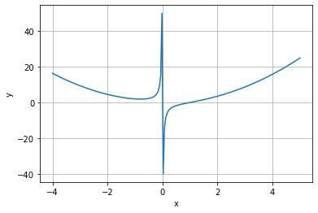

```python
x = np.linspace(-4.0, 5.0, 200)
y = (x**3 - 1)/(x)
plt.plot(x,y)
plt.grid()
plt.xlabel('x')
plt.ylabel('y')
```

which is $\text{V}(xy-x^{3}+1)$. In essence, $$y=\frac{f(x)}{g(x)} \Leftrightarrow yg(x)-f(x)=0,$$ which mean for our example, $$y=\frac{x^{3}-1}{x} \Leftrightarrow xy-x^{3}+1=0.$$ Notationally we have, $$\text{V}(xy-x^{3}+1)=\{(x,y) \in \R^{2} | xy-x^{3}+1=0\} = \{(x,y) \in \R^{2} | \frac{x^{3}-1}{x}\}.$$

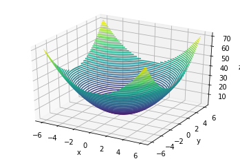

```python
def f(x, y):
    return x ** 2 + y ** 2

x = np.linspace(-6, 6, 30)
y = np.linspace(-6, 6, 30)

X, Y = np.meshgrid(x, y)
Z = f(X, Y)

fig = plt.figure()
ax = plt.axes(projection='3d')
ax.contour3D(X, Y, Z, 50)
ax.set_xlabel('x')
ax.set_ylabel('y')
ax.set_zlabel('z');
```

A similar process for three dimensional surface graphs.

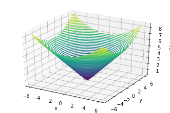

```python
def f(x, y):
    return np.sqrt(x**2+y**2)

x = np.linspace(-6, 6, 30)
y = np.linspace(-6, 6, 30)

X, Y = np.meshgrid(x, y)
Z = f(X, Y)

fig = plt.figure()
ax = plt.axes(projection='3d')
ax.contour3D(X, Y, Z, 50)
ax.set_xlabel('x')
ax.set_ylabel('y')
ax.set_zlabel('z');
```

In linear algebra the varieties are called linear varieties, which are the linear system of equations $Ax=b$; where $A$ is a size $m \text{x} n$, and $x$ and $b$ are vectors of size $n \text{x} x 1$.

**Lemma 2.** If $V$, $W \subseteq k^{n}$ are affine varieties, then so are $V \cup W$ and $V \cap W$.
**PROOF.** Suppose that $V=\text{V}(f_1,...,f_s)$ and $W=\text{V}(g_1,...,g_t)$. Then we claim that $$V \cap W=\text{V}(f_1,...,f_s,g_1,...,g_t),$$ $$V \cup W=\text{V}(f_ig_i|1 \leq i \leq s, 1 \leq j \leq t).$$ The first equality is trivial to prove: being in $V \cap W$ means that both $f_1,...,f_s$ and $g_1,...,g_t$ vanish, which is the same as $f_1,...,f_s,g_1,....,g_t$ vanishing.
The second equality takes a little more work. If $(a_1,...,a_n) \in V$, then all of the $f_i$'s vanish at this point, which implies that all of the $f_ig_j$'s also vanish at $(a_1,...,a_n)$. Thus, $V \subseteq \text{V}(f_ig_j)$, and $W \subseteq \text{V}(f_ig_j)$ follows similarly. This proves that $V \cup W \subseteq \text{V}(f_ig_i)$. Going the other way, choose $(a_1,...,a_n)\in \text{V}(f_ig_j)$. If this lies in $V$, then we are done, if not, then ${f_i}_0(a_1,...,a_n) \ne 0$ for some $i_0$. Since ${f_i}_0 g_j)$ vanishes at $(a_1,...,a_n)$ for all $j$, the $g_j$'s must vanish at this point, proving that $(a_1,...,a_n) \in W)$. This shows that $\text{V}(f_ig_i) \subseteq V \cup W$. $\square$ </p>

- Excelent YouTube videos to accompany these notes are the following:
  - *1.1.2 Two meanings of f=0, equivalence for infinite fields, defining algebraically closed*: https://www.youtube.com/watch?v=2ywKJO82KCU&list=PLuk3I0lb-B5VZglbeHfzOZ5QJKdABpQU4&index=2
- Warm-up 1.2: Questions #1,#4,#5 and #6 Due Date: 8/27/2021
  - Solution to Warm-up 1.2

### $\S$ 1.3 Parametrizations of Affine Varieties

**Rational Functions:**

> "A function $f(x)$ is called a rational function if and only if it can be written in the form $$ f(x)=\frac{P(x)}{Q(x)}$$ Where $P$ and $Q$ are [polynomial functions](https://en.wikipedia.org/wiki/Polynomial#Polynomial_functions) of $x$ and $Q$ is not the zero function. The domain of $f$ is the set of all values of $x$ for which the demoninator $Q(x)$ is not zero.
> However, if $P$ and $Q$ have a non-constant poly greatest common divisor $R$, then setting $P=P_1RQ$ and $Q=Q_1R$ produces a rational function $$ f_1(x)=\frac{P_1(x)}{Q_1(x)}$$ Which may have a larger domain than $f(x$, and is equal to $f(x)$ on the domain of $f(x)$. It is a common usage to identify $f(x)$ and $f_1(x)$, that is to extend "by continuity" the domain of $f(x)$ to that of $f_1(x)$. Indeed, one can define a rational fraction as an equivalence class of fractions of polynomials, where two fractions $\frac{A(x)}{B(x)}$ and $\frac{C(x)}{D(X)}$ are considered equivalent if $A(x)D(x)=B(x)C(x)$. In this case $\frac{P(x)}{Q(x)}$ is equivalent to $\frac{P_1(x)}{Q_1(x)}$.
> A **proper rational function** is a rational function in which the degree of $P(x)$ is no greater than the degree of $Q(x)$ and both are [real polynomials](https://en.wikipedia.org/wiki/Polynomial#real_polynomial)." ([Wikipedia](https://en.wikipedia.org/wiki/Rational_function))

**Definition 1.** Let $k$ be a field. A **rational function** in $t_1,...,t_m$ with coefficients in $k$ is a quotient $f/g$ of two polynomials $f$, $g \in k[t_1,...,t_m]$, where $g$ is not the zero polynomial. Furthermore, two rational functions $f/g$ and $f^{'}/g^{'}$ are equal provided that $g^{'}f=gf^{'}$ in $k[t_1,...,t_m]$. Finally, the set of all rational functions in $t_1,...,t_m$ with coefficients in $k$ is denoted $k(t_1,...,t_m)$.

**Rational parametric representation:**

### $\S$ 1.4 Ideals

Ideals are the means for computating with affine varieties.

**Definition 1.** A subset $I \subseteq k[x_1,...,x_n]$ is an **ideal** if it satisfies: (i) $0 \text{zero polynomial} \in I$  
(ii) If (polynomials) $f$, $g \in I$, then $f+g \in I$.  
(iii) If a polynomial $f \in I$ and (any polynomial) $h \in k[x_1,...,x_n]$, (which is part of an commutative ring $k[x_1,...,x_n]$), then $hf \in I$.

Ideals play an important roles in constructing computational Algebriac Geometric algorithms, as it is the language for affine varieties and affine spaces. An natural first ideal to present the reader is the ideal that is generated by a finite number of polynomials.

**Definition 2.** Let $f_1,...,f_s$ be polynomials in $k[x_1,...,x_n]$. Then we set $$\langle f_1,...,f_s \rangle = \Big\{ \sum_{i=1}^{s} h_if_i | h_1,...,h_s \in k[x_1,...,x_n] \Big\}$$ The crucial fact is that $\langle f_1,...,f_s \rangle$ is an *ideal* (Cox et al., 2015).

**Lemma 3.** If $f_1,...,,f_s \in k[x_1,...,x_n]$ (polynomial ring), then $\langle f_1,...,f_s \rangle$ is an ideal of $k[x_1,...,x_n]$ (polynomial ring). We will call $\langle f_1,...,f_s \rangle$ the **ideal generated by** $f_1,...,f_s$.
**PROOF.** First, $0 \in \langle f_1,...,f_s \rangle$ since $0=\sum_{i=1}^{s} 0*f_i$. Next, suppose that $f=\sum_{i=1}^{s} p_if_i$ and $g=\sum_{i=1}^{s} q_if_i$, and let $h \in k[x_1,...,x_n]$. Then the equations $$f+g=\sum_{i=1}^{s} (p_i+q_i)f_i,$$ $$hf=\sum_{i=1}^{s} (hp_i)f_i$$ complete the proof that $\langle f_1,...,f_s \rangle$ is an ideal. $\square$

In essence the ideal is generated by a linear combination of a set of polynomials $f_1,...,f_s$; where instead of multiplying a scalar value across the set of polynomials, a set of polynomials $h_1,...,h_s$ is multiplied with $f_1,...,f_s$ to form the ideal $\langle f_1,...,f_s \rangle$ through this linear combination, $h_1f_1+h_2f_2+\cdots+h_sf_s$. In the text, the author reference to the results of the operation of adding, subtracting, multiplying and scaling polynomials is *"polynomial consequence"*.

**Proposition 4.** If $f_1,...,f_s$ and $g_1,...,g_s$ are bases of the same ideal in $k[x_1,...,x_n]$, so that $\langle f_1,...,f_s \rangle = \langle g_1,...,g_s \rangle$, then we have $\text{V}(f_1,...,f_s)=\text{V}(g_1,...,g_s)$.  
**PROOF.**

In other words, the operations established through the axioms of commutative rings, allows for the aglebraic manipulation of polynomials in the commutative ring $k[x_1,...,x_n]$ to form new polynomials in the commutative, which then form the ideal $\langle f_1,...,f_s \rangle. As stated by (Cox et al., 2015) the ideal $\langle f_1,...,f_s \rangle is the set of all *"polynomial consequence"*, aka, algebraic manipulated polynomials of the original polynomai system of equations, $f_1=f_2=\cdots=f_s=0$. As well the original polynomial system of equations forms the basis of the *ideal* $I$. By Hilbert Basis theorem, which states that the every ideal $i$ of the polynomial ring $k[x_1,...,x_n]$ is finitely generated by the basis found $\in k[x_1,...,x_n]$.

**Example (Textbook):** Consider the variety $\text{V}(2x^{2}+3y^{2}-11,x^{2}-y^{2}-3)$, which has the following ideal, $\langle 2x^{2}+3y^{2}-11,x^{2}-y^{2}-3 \rangle = (x^{2}-4,y^{2}-1)$. We can simplify the process of discerning the variety from this ideal with this proposition: $$\text{V}(2x^{2}+3y^{2}-11,x^{2}-y^{2}-3) = \text{V}(x^{2}-4,y^{2}-1)=\{(\pm 2,\pm 1)\}$$ Hence by changing the basis of the ideal, we are able to discern the variety from the ideal much easier.

**Defintion 5.** Let $V \subseteq k^{n}$ be an affine variety. The we set $$\text{I}(V)=\langle f \in k[x_1,...,x_n]|f(a_1,...,a_n)=0 \text{ for all } (a_1,...,a_n) \in \text{V} \rangle.$$

**Note:** $\text{I}(V)$ is an ideal.

**Lemma 6.** If $V \subseteq k^{n}$ is an *affine variety*, then $\text{I}(v) \subseteq k[x_1,...,x_n]$ is an ideal. We will call $\text{I}(V)$ the **ideal of** $V$.
**PROOF.** It is obvious that $0 \in \text{I}(V)$ since the zero polynomial vanishes on all of $k^{n}$, and so, in particular it vanishes on $V$. Next, suppose that $f$, $g \in \text{I}(V)$ and $h \in k[x_1,...,x_n]$.
Let $(a_1,...,a_n)$ be an arbitrary point of $V$. Then $$f(a_1,...,a_n)+g(a_1,...,a_n)=0+0=0,$$ $$h(a_1,...,a_n)*f(a_1,...,a_n)=h(a_1,...,a_n)*0=0,$$ and it follows that $\text{I}(V)$ is an ideal. $\square$

> The example of the twisted cubic is very suggestive. We started with the polunomials $y-x^{2}$ and $z-x^{3}$, used them to define an affine variety, took all functions vanishing on the variety, and got back the ideal generated by the two polynomials. It is natural to wonder if this happens in general. So take $f_1,...,f_s \in k[x_1,...,x_n]$. This give us $$\text{polynomials}\qquad\: \text{variety}\qquad\qquad\, \text{ideal}\qquad$$ $$f_1,...,f_s \rightarrow \text{V}(f_1,...,f_s) \rightarrow \text{I}(\text{V}(f_1,...,f_s)),$$ and the natural question to ask is whether $\text{I}(\text{V}(f_1,...,f_s))= \langle f_1,...,f_s \rangle$? The answer, unfortunately, is not always yes. Here is the best answer we can give at this point.

> From: (Cox et al., 2015, pg. 34)

**Proposition 8.** Let $V$ and $W$ be affine variety in $k^{n}$. Then:  
(i) $V \subseteq W$ if and only if $\text{I}(V) \supseteq \text{I}(W)$.  
(ii) $V=W$ if and only if $\text{I}(V) = \text{I}(W)$

- Excelent YouTube videos to accompany these notes are the following:
  - *1.4.1 Ideals, Their Interpretation, and Their Relation to Affine Varieties*: https://www.youtube.com/watch?v=DMZnmWkR8e4&t=26s
  - *1.4.2 The ideal of a variety, some examples*: https://www.youtube.com/watch?v=as9i1m_AXsg&list=PLuk3I0lb-B5VZglbeHfzOZ5QJKdABpQU4&index=12 -*1.4.3 The Ideal Generated by f1,..., fs and the Ideal of V(f1,...,fs), and Affine Variety Subsets*: https://www.youtube.com/watch?v=z3tfL0U7QVU&list=PLuk3I0lb-B5VZglbeHfzOZ5QJKdABpQU4&index=13
- Warm-up 1.4: Questions #3a,#3b,#5,#15, #8 and #11 Due Date:
  - Solution to Warm-up 1.4

### $\S$ 1.5 Polynomials of One Variable

**Division algorithm:** Commonly referred to as simply *long division* in high school, this methodology is used to divide polynomials by polynomials. This rather rudimentary algorithm has profound consequences, and implications to far more advance mathematical topics such as structures of ideals and *greatest common divisors*. With the development and extrapolation of this elementary algorithm, we will be able solve system of special polynomials.

**Greatest Common Divisor (GCD):**

> The greatest common divisor (GCD) of two nonzero integers $a$ and $b$ is the greatest positive integer $d$ sucht that $d$ is a divisor of both $a$ and $b$; this is, therefore integers $e$ and $f$ such that $a=de$ and $b=df$, and $d$ is the largest such integer. The GCD of $a$ and $b$ is generally denoted $gcd(a,b)$.

> From Wikipedia: Great Common Divisor: https://en.wikipedia.org/wiki/Greatest_common_divisor

**Definition 1.** Given a nonzero polynomial $f \in k[x]$, let $$f=c_0x^{m} + c_1x^{m} + c_1x^{m-1} + \cdots + C_m.$$ where $c_i \in k$ and c_0 \ne 0$ [thus, $m = deg(f)]. Then we say that $c_0x^{m}$ is the leading term of $f$, weitten $LT(f)=c_0x^{m}$. **Defintion 2. (The Division Algorithm).** Let $k$ be a field and let $f$ be a nonzero polynomial in $k[x]$. Then every $f \in k[x]$ can be written as $$f=qg+r,$$ where $q,r \in k[x]$, and either $r=$ or $deg(r) < deg(r)$. Furthermore, $q$ and $r$ are unique, and there is an algorithm for finding $q$ and $r$.
**PROOF.** add the proof from pg. 39 later.

**Corollary 3.** If $k$ is a field and $f \in k[x]$ is a nonzero polynomial, then $f$ has at mmost $deg(f)$ roots in $k$.  
**PROOF.** We will use induction on $m = deg(f)$. When $m=0$, $f$ is a nonzero constant, and the corollary is obviously true. Now assume that the corollay holds for all polynomials of degree $m-1$. and let $f$ have degree $m$. If $f$ has no roots in $k$, then we are done. So suppose $a$ is a root in $k$. If we divide $f$ by $x-a$, then proposition 2 tells us that $f=q(x-a)+r$, ehrte $r\in k$ since $x-a$ has degree one. To determine $r$, evaluate both sides at $x=a$, which give $0=f(a)=q(a)(a-a)+r=r$. It follows that $f=q(x-a)$. Note also that $q$ has degree $m-1$.  
We claim that any root of $f$ other than $a$ is also a root of $q$. To see this, let $b \ne a$ be a root of $f$. Then $0=f(b)=q(b)(b-a)$ implies that $q(b)=0$ since $k$ is a field. Since $q^$ has at most $m-1$ roots by our inductive assumption, $f$ has most $m$ roots in $k$. This completes the proof. $\square$

**Corollary 4.** If $k$ is a field, then every ideall fo $k[x]$ can be written as $(f)$ for some $f \in k[x]$. Furthermore, $f$ is unique up to multiplication by a nonzero constant in $k$.
**PROOF.** Take an ideal $\text{I} \subseteq k[x]$. If $I=\{\}$, then we are done since $I=\langle 0 \rangle$. Otherwise, let $f$ be a nonzero polynomial of minimum degree contained in $I$. We claim that $\langle f \rangle = I$. The inclusion $\langle f \rangle \subseteq I$ is obvious since $I$ is an ideal. Going the other way, take $g \in I$. By division algorithm (Proposition 2), we have $g=gf+r$, where either $r=0$ or $deg(r) < deg(f)$. Since $I$ is an ideal, $g,f \in I$ and, thus, $r=g-gf \in I$. If $r$ were not zero, then $deg(r) < deg(f)$, which would contradict our choice of $f$. Thus, $r=0$, so that $g=gf \in \langle f \rangle$. This proves that $I = \langle f \rangle$.
nbsp; To study uniqueness, suppose that $\langle f \rangle = \langle g \rangle$. Then $f \in \langle f \rangle$ implies that $f=hg$ for some polynomial $h$. Thus, $$deg(f)=deg(h)+deg(g)$$ so that $deg(f) \geq deg(g)$. The argument with $f$ and $g$ interchanged shows $deg(f) \leq deg(g)$, and it follows that $deg(f)=deg(g)$. Then (the equation above) impplies $deg(h)=0$, so that $h$ is a nonzero constant. $\square$

**Definition 5.** A **greatest common divisor** of polynomials $f,g \in k[x]$ is a polynomial $h$ such that:  
(i) $h$ divides $f$ and $g$.  
(ii) If $p$ is another polynomial which divide $f$ and $g$, then p divides $h$. When $h$ these properties, we write $h=gcd(f,g)$.  
**Proposition 6.** Let $f,g \in k[x]$. Then:  
(i) $gcd(f,g)$ exists and is unique up to multiplication by a nonzero constant in $k$.  
(ii) $gcd(f,g)$ is a generator of the ideal $\langle f,g \rangle$.  
(iii) There is an algorithm for finding $gcd(f,g)$.  
**PROOF.** Add proof from pg. 42 later.

**Defintion 7.** A **greatest common divisor** of polynomials $f_1,...,f_s \in k[x]$ is a polynomial $h$ such that:  
(i) $h$ divides $f_1,...,f_s$.  
(ii) If $p$ is another polynomial which divides $f_1,...,f_s$, then $p$ divides $h$.  
When $h$ has these properties, we write $h=gcd(f_1,...,f_s)$.  
**Proposition 8.** Let $f_1,...,f_s \in k[x]$, where $s \geq 2$. Then:  
(i) $gcd(f_1,...,f_s)$ exists and is unique up to multiplication by a nonzero constant in $k$.  
(ii) $gcd(f_1,...,f_s)$ is a generator of the ideal $\langle f_1,...,f_s \rangle$.  
(iii) If $s \geq 3$, then $gcd(f_1,...,f_s)=gcd(f_1,gcd(f_2,...,f_S))$.  
(iv) There is an algorithm for finding $gcd(f_1,...,f_s)$.  
**PROOF.** another exercise proof.

The numerical implementatin of the division algorithm is the Euclidean algorithm. Here the the extended code implementation of Euclidean algorithm in Python; I borrowed this Python code from an article on GeeksforGeeks: [Euclidean algorithms (Basic and Extended)](https://www.geeksforgeeks.org/euclidean-algorithms-basic-and-extended/).

```python
# Python program to demonstrate working of extended
# Euclidean Algorithm

# function for extended Euclidean Algorithm
def gcdExtended(a, b):

    # Base Case
    if a == 0 :
        return b, 0, 1

    gcd, x1, y1 = gcdExtended(b%a, a)

    # Update x and y using results of recursive
    # call
    x = y1 - (b//a) * x1
    y = x1

    return gcd, x, y


# Driver code
a, b = 35,15
g, x, y = gcdExtended(a, b)
print("gcd(", a , "," , b, ") = ", g)
```

```
gcd( 35 , 15 ) =  5
```

- Excelent YouTube videos to accompany these notes are the following:
  - *1.5.1 The Division Algorithm and an Implication for Roots of m-th Degree Polynomials*: https://www.youtube.com/watch?v=8C8bIi2SEdI&list=PLuk3I0lb-B5VZglbeHfzOZ5QJKdABpQU4&index=14
  - *1.5.2 $k[x]$ is a Principal Ideal Domain, Greatest Common Divisor*: https://www.youtube.com/watch?v=62t29B1xwLk&list=PLuk3I0lb-B5VZglbeHfzOZ5QJKdABpQU4&index=15 -*1.5.3 The Euclidean Algorithm and Generators of Ideals in k[x]*: https://www.youtube.com/watch?v=ul9GqHV_GhQ&list=PLuk3I0lb-B5VZglbeHfzOZ5QJKdABpQU4&index=16
- Warm-up 1.5: Questions #9,#11,#12,#3, and #17 Due Date:
  - Solution to Warm-up 1.5

## Chapter 2: Grobner Bases

### $\S$ 1 Introduction

**Example #1 (Textbook):** When $n=1$, we solved the ideal description problem in $\S$ of Chapter 1. Namely, given an ideal $I \subseteq k[x]$, we showed that $I = \langle g \rangle$ for some $g \in k[x]$ (see Corollary 4 of Chapter 1, $\S$5). So ideals have an especially simple description in this case.  
We also saw in $\S$5 of chapter 1 that the solution of the dideal membership problem follows easily from the division algorithm: given $f \in k[x]$, to check whether $f \in I = \langle g \rangle$, we divide $g$ into $f$:

$$f=q*g+r,$$

where $q,r \in k[x]$ and $r=0$ or $deg(r) < deg(g)$. Then we proved that $f \in I$ if and only if $r=0$. Thus, we have an algorithmic test for ideal membership in the case $n=1$.

**Example #2:** next, let $n$ (the number of variables) be arbitrary, and consider the problem of solving a system of polynomials equations:

$$ \begin{alignat*}{7} a_{11}x_1 &{}+ \cdots & & &+ a_{1n}x_n + b_1 &= 0 \\ \vdots & & & & \vdots & {} \\ a_{m1}x_1 &{}+ \cdots & & &+ a_{mn}x_n + b_m &= 0 \\ \end{alignat*} $$

where each polynomial is linear (total degree 1).  
For example, consider the system

\begin{alignat*}{7} 2x_1 &+ 3x_2 - x_3 &= 0 \\ {}x_1 &+ \ \, x_2 - \, 1 &= 0 \\ {}x_1 &+ \ \, x_3 - \, 3 &= 0 \\ \end{alignat*}

```python
import numpy as np

def LU(A):

    #Get the number of rows
    n = A.shape[0]

    U = A.copy()
    L = np.eye(n, dtype=np.double)

    #Loop over rows
    for i in range(n):

        #Eliminate entries below i with row operations
        #on U and reverse the row operations to
        #manipulate L
        factor = U[i+1:, i] / U[i, i]
        L[i+1:, i] = factor
        U[i+1:] -= factor[:, np.newaxis] * U[i]

    return L, U
```

### $\S$ 2 Orderings on Monomials in $k[x_1,...,x_n]$

**Definition 1.** A **monomial ordering** $>$ on $k[x_1,...,x_n]$ is a relation $>$ on $\Z_{\geq0}^{n}$, satisfying:  
1. $>$ is a total (or linear) ordering on $\Z_{\geq0}^{n}$.  
2. If $\alpha > \beta$ and $\gamma \in \Z_{\geq0}^{n}$, then $\alpha+\gamma > \beta+\gamma$.  
3. $>$ is a well-ordering on $\Z_{\geq0}^{n}$. This means that every nonempty subset of $\Z_{\geq0}^{n}$ has a smallest element under $>$. In other words, if $A \subseteq \Z_{\geq0}^{n}$ is nonempty, then there is $\alpha \in A$ such that $\beta > \alpha$ for every $\beta \ne \alpha$ in $A$.

**Lemma 2.** An order relation $>$ on $\Z_{\geq 0}^{n}$ is a well-ordering if and only if every strictly decreasing sequence in $\Z_{\geq 0}^{n}$ $$\alpha(1) > \alpha(2) > \alpha(3) > \cdots$$ eventually terminates.
**PROOF.** We will prove this contrapositive form: $>$ is not a well-ordering if and only if there ais an infinite strictly decreasing sequence in $>$ on $\Z_{\geq 0}^{n}$.
If $>$ is not a well-ordering, then some nonempty subset $S \subseteq \Z_{\geq 0}^{n}$ has no least element. Now pick $\alpha(1) \in S$. Since $\alpha(1)$ is not the least element, we can find $\alpha(1) > \alpha(2)$ in $S$. Then $\alpha(2)$ is also not the least element, so there is $\alpha(2) > \alpha(3)$ in $S$. Continuing this way, we get an infinite strictly decreasing sequence $$\alpha(1) > \alpha(2) > \alpha(3) > \cdots.$$ Conversely, given such an infinite sequence, then $\{\alpha(1), \alpha(2) \alpha(3),...\}$ is a non-empty subset of $\Z_{\geq 0}^{n}$ with no least element, and thus, $>$ (ordering) is not a well-ordering. $\square$

For an sequence to possess an smallest element, it must terminate, otherwise the sequence could possess exceedingly smaller element somewhere in its infinite sequence. And here is the importance of **Lemma 2**, as any algorithm must terminate, the sequence of terms that is feed into the algorithm must be finite.

**Definition 3 (Lexicographic Order).** Let $\alpha = (\alpha_1,...,\alpha_n)$ and $\beta = (\beta_1,...,\beta_n)$ be in $\Z_{\geq 0}^{n}$. We say say $\alpha >_{\text{lex}} \beta$ if the lestmost nonzero entry of the vector difference $\alpha - \beta \in \Z_{\geq 0}^{n}$ is positive. We will write $x^{\alpha} >_{\text{lex}} x^{\beta}$ if $\alpha >_{\text{lex}} \beta$.

**Example (textbook)**
a. $(1,2,0) >_{\text{Lex}} (0,3,4)$ since $\alpha-beta = (1,-1,-4)$. $$xy^{2}z^{0} >_{\text{Lex}} x^{0}y^{3}z^{4} \equiv xy^{2} >_{\text{Lex}} y^{3}z^{4}$$ b. $(3,2,4) >_{\text{Lex}} (3,2,1)$ since $\alpha-\beta = (0,0,3)$. $$x^{3}y^{2}z^{4} >_{\text{Lex}} x^{3}y^{2}z^{1}$$ c. The variables $x_1,...,x_n$ are ordered in the *usual* way (means) by the lex ordering: $$(1,0,...,0) >_{\text{Lex}} (0,1,0,...,0) >_{\text{Lex}} \cdots >_{\text{Lex}} (0,0,...,0,1).$$ so $x_1 >_{\text{Lex}} x_2 >_{\text{Lex}} \cdots >_{\text{Lex}} x_n$.

**Proposition 4.** The lex ordering on $\Z_{\geq 0}^{n}$ is a monomial ordering.
**PROOF.** (i) That $>_{\text{Lex}}$ is a total ordering follow directly from the definition and the fact that the usual numerical order on $\Z_{\geq 0}^{n}$ is a total ordering.
(ii) If $\alpha >_{\text{Lex}} \beta$, then we have that the leftmost nonzero entry in $\alpha-\beta$, say $\alpha_i - \beta_i$, is positive. But $x^{\alpha}*x^{\gamma}=x^{\alpha + \gamma}$ and $x^{\beta}*x^{\gamma}=x^{\beta + \gamma}$. Then in $(\alpha + \gamma)$ - $(\beta - \gamma)=\alpha - \beta$, the leftmost nonzero entry is again (non-negataive/positive) $\alpha_i - \beta_i > 0$.
(iii) Suppose that $>_{\text{Lex}}$ were not a well-ordering. Then by **Lemma 2**, there would be an infinitely strictly descending sequence $$\alpha(1) >_{\text{Lex}} \alpha(2) >_{\text{Lex}} \alpha(3) >_{\text{Lex}} \cdots$$ of elements of $\Z_{\geq 0}^{n}$. We will show that this leads to a contradiction.
Consider the first entries of the vectors $\alpha(i) \in \Z_{\geq 0}^{n}$. By the definition of the lex order, these first entries form a nonincreasing sequence of nonnegative itegers. Since $\Z_{\geq 0}^{n}$ is well-ordered, first entries of the $\alpha(i)$ must "stablize" eventually. In other words, there exists an $l$ such that all the first entries of the $\alpha(i)$ with $i \geq l$ are equal.
Beginning at $\alpha(l)$, the second and subsequent entries come into play in determining the lex order. The second entries of $\alpha(l), \alpha(l+1),...$ form a nonincreasing sequence. By the same reasoning as bvefore, the second entries "stablize" eventually as well. Continuing in the same way, we see that for some $m$, the $\alpha(m),\alpha(,+1),...$ all are equal. This contradicts the fact that $\alpha(m) >_{\text{Lex}} \alpha(m+1)$. $\square$

Simply **proposition 4**: states that the various lex ordering arrangements are able arrange terms of a polynomial in terms of a monomial ordering.

**Definition 5 (Graded Lex Order).** Let $\alpha$, $\beta \in \Z_{\geq 0}^{n}$. We say $\alpha >_{\text{grLex}} \beta$ if

$$|\alpha|=\sum_{i=1}^{n} \alpha_i > |\beta| = \sum_{i=1}^{n} \beta_i, \text{ or } |\alpha|=|\beta| \text{ and } $\alpha >_{\text{grLex}} \beta.$$

**Example (textbook):**  
a. $(1,2,3) >_{\text{grLex}} (3,2,0)$ since $|(1,2,3)|= 6 > |(3,2,0)|=5$.

$$xy^{2}z^{4} >_{\text{grLex}} x^{3}y^{2}$$

b. $(1,2,4) >_{\text{grLex}} (1,1,5)$ since $|(1,2,3)|=7=|(1,1,5)|$, then by Lex, $(1,2,4) >_{\text{Lex}} (1,1,5)$ since $\alpha-\beta=(0,1,-1)$

$$xy^{2}z^{4} >_{\text{grLex}} xyz^{5}$$

**Definition 6 (Graded Reverse Lex Order).** Let $\alpha$, $\beta \in \Z_{\geq 0}^{n}$. We say $\alpha >_{\text{grevLex}} \beta$ if $$|\alpha|=\sum_{i=1}^{n} \alpha_i > |\beta|=\sum_{i=1}^{n} \beta_i,$$ or $|\alpha|=|\beta|$ and the rightmost nonzero entry of $\alpha - \beta \in \Z_{\geq 0}^{n}$ is negative.

**Example (textbook):**
a. $(4,7,1) >_{\text{grevLex}} (4,2,3)$ since $|(4,7,1)|=12 > |(4,2,3)|=9$ $$x^{4}y^{7}z >_{\text{grevLex}} x^{4}y^{2}z^{3}$$ b. $(1,5,2) >_{\text{grevLex}} (4,1,3)$ since $|(1,5,2)|=8=|(4,1,3)|$ and by Lex, $(1,5,2)-(4,1,3)=(-3,4,-1)$ $$xy^{5}z^{2} >_{\text{grevLex}} x^{4}yz^{3}$$

**Definition 7.** Let $f=\sum_{\alpha} a_{\alpha}x^{\alpha}$ be nonzero polynomial in $k[x_1,...,x_n]$ and let $>$ be a monomial order.
(i) The **multidegree** of $f$ is $$multideg(f) = \max (\alpha \in \Z_{\geq 0}^{n} | a_{\alpha} \ne 0)$$ (the maximum is taken with respect to >).
(ii) The **leading coefficient** of $f$ is

$$LC(f)=a_{\text{multideg}(f)} \in k.$$

(iii) The **leading monomial** of $f$ is

$$LM(f)=x^{\text{multideg}(f)}$$

(with coefficient 1).  
(iv) The **Leading Term** of $f$ is

$$LT(f)=LC(f)*LM(f).$$

- Excelent YouTube videos to accompany these notes are the following:
  - *1.5.1 The Division Algorithm and an Implication for Roots of m-th Degree Polynomials*: https://www.youtube.com/watch?v=8C8bIi2SEdI&list=PLuk3I0lb-B5VZglbeHfzOZ5QJKdABpQU4&index=14
- Warm-up 2.2: Questions #1,#3,#6,#9, and #10 Due Date:
  - Solution to Warm-up 2.2

### $\S$ 3 A Division Algorithm in $k[x_1,...,x_n]$

**Theorem 3 (Division Algorithm in k[x_1,...,x_n]).** Let $>$ be a monomial order on $\Z_{\geq 0}^{n}$, and let $F=(f_1,...,f_s)$ be an ordered s-tuple of polynomials in $k[x_1,...,x_n]$. Then every $f \in k[x_1,...,x_n]$ can be written as

$$f=q_1f_1+\cdots+q_sf_s+r,$$

where $q_i$, $r \in k[x_1,...,x_n]$, and either $r=0$ (remainder equal zero) or (the remainder) is a linear combination, with coefficients in $k$, of monomials, none of which is divisible by any of $LT(f_1),...,LT(f_s)$. We call $r$ a **remainder** of $f$ on division by $F$. Furthermore, if $q_if_i \ne 0$, then

$$\text{multideg}(f) \geq \text{multideg}(g_if_i).$$

- Excelent YouTube videos to accompany these notes are the following:
  - *1.5.1 The Division Algorithm and an Implication for Roots of m-th Degree Polynomials*: https://www.youtube.com/watch?v=8C8bIi2SEdI&list=PLuk3I0lb-B5VZglbeHfzOZ5QJKdABpQU4&index=14
- Warm-up 1.5: Questions #1, #5 and #10 Due Date:
  - Solution to Warm-up 2.3

### $\S$ 4 Monomial Ideals and Dickson's Lemma$